# Analysis of crime incidents BY Ramya

2023-06-26

For the final assignment I have choosen the dataset from Kaggle “PDI (Police Data Initiative) Crime Incidents”. The dataset contains the incidents of cincinnati. It contains all the details of incidents. It has total of 40 columns. Like, Victim details, Suspect details, Area codes, Hate bias, type of offense etc. It has total rows of 503,231.

It is good to analyse the what type of victims are in more danger, in which area are the incidents taking place etc. In this final assignment, using the dataset from kaggle I will analyse 5 things.

1. What are the most common type of offenses occuring?
2. Victims of what age are high?
3. What are the Proportion of the suspect ages ?
4. What is the Comparison of Victim Gender and Suspect Gender probabilty?
5. What are the most Uniform Crime Reporting of total number of victims?

First we will load the necessary packages

```r
library(tidyverse) #load tidyverse package
```

```r
library(ggplot2) #load ggplot2 package
library(dplyr) #load dplyr package
library(tidyr) #load tidyr package
```

```r
crime = read.csv("/Users/ramyameka/Downloads/Crime_Incidents.csv") #read CSV file
```

```r
glimpse(crime)  #display summary of crime dataset
```

```
## Rows: 503,231
## Columns: 40
## $ INSTANCEID                     <chr> "CA0E1120-DD58-4D7C-A09B-BA1F1E8598D3",…
## $ INCIDENT_NO                    <chr> "239017687", "239017683", "239017684", …
## $ DATE_REPORTED                  <chr> "06/25/2023 11:05:00 AM", "06/25/2023 1…
## $ DATE_FROM                      <chr> "06/21/2023 12:00:00 AM", "06/25/2023 0…
## $ DATE_TO                        <chr> "06/25/2023 11:00:00 AM", "06/25/2023 1…
## $ CLSD                           <chr> "", "", "H--WARRANT ISSUED", "F--CLEARE…
## $ UCR                            <int> 600, 600, 600, 1493, 862, 862, 600, 243…
## $ DST                            <chr> "3", "3", "4", "3", "4", "3", "3", "4",…
## $ BEAT                           <chr> "2", "1", "1", "2", "6", "2", "3", "4",…
## $ OFFENSE                        <chr> "THEFT", "THEFT", "THEFT", "CRIMINAL DA…
## $ LOCATION                       <chr> "47-STREET", "48-PARKING LOT", "38-VARI…
## $ THEFT_CODE                     <chr> "24O-MOTOR VEHICLE THEFT", "24O-MOTOR V…
## $ FLOOR                          <chr> "", "", "", "", "", "", "", "", "", "",…
```

[output cut: 27 more lines]

```r
sum(is.na(crime)) #calculate the total number of null values
```

```
## [1] 396427
```

```r
crime<-na.omit(crime) #Remove the null values
```

Create bar plot for the top 5 offenses

```r
offense_counts <- crime %>%
  count(OFFENSE) %>% #count the occurrences of each offense type
  top_n(5, n)  #select 5 offenses

offense_counts #view top 5 offenses
```

```
##                         OFFENSE     n
## 1            AGGRAVATED ROBBERY 16520
## 2                       ASSAULT 32758
## 3 CRIMINAL DAMAGING/ENDANGERING 22864
## 4             DOMESTIC VIOLENCE 12223
## 5                         THEFT 44849
```

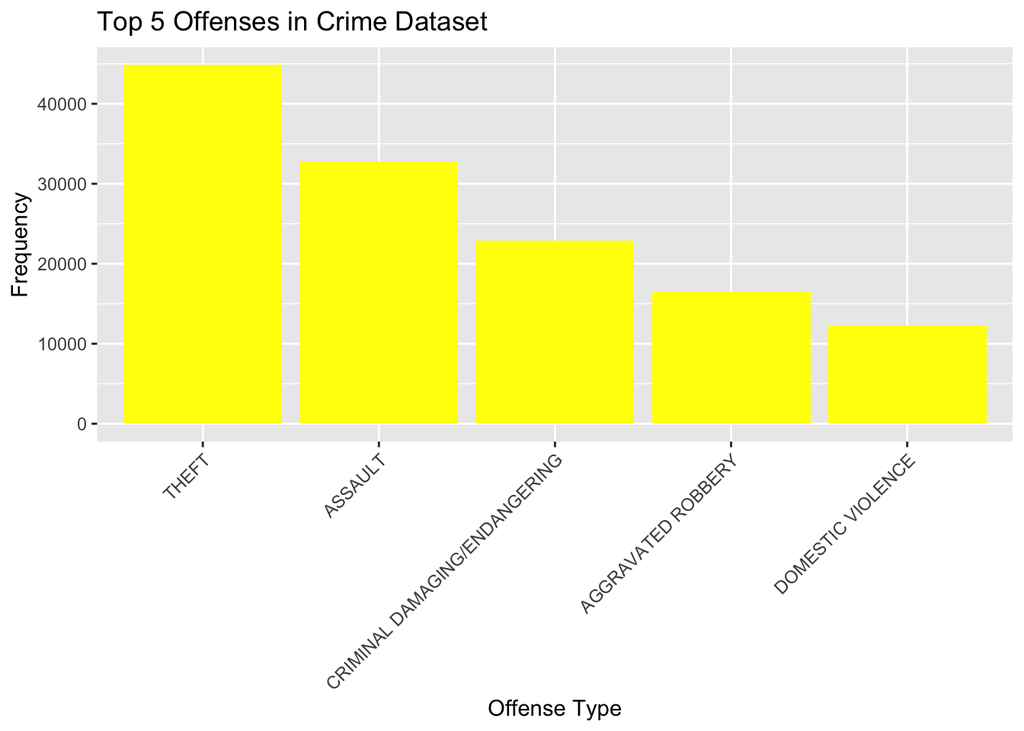

```r
ggplot(offense_counts, aes(x = reorder(OFFENSE, -n), y = n)) +  #create ggplot with offense_counts data with x and y variables
  geom_bar(stat = "identity", fill = "yellow") + #add bar plot using blue fill color
  theme(axis.text.x = element_text(angle = 45, hjust = 1)) + #customize x-axis text angle and justification
  labs(x = "Offense Type", y = "Frequency", title = "Top 5 Offenses in Crime Dataset") #add x-axis, y-axis and title labels
```

Create Bar plot for Victim ages

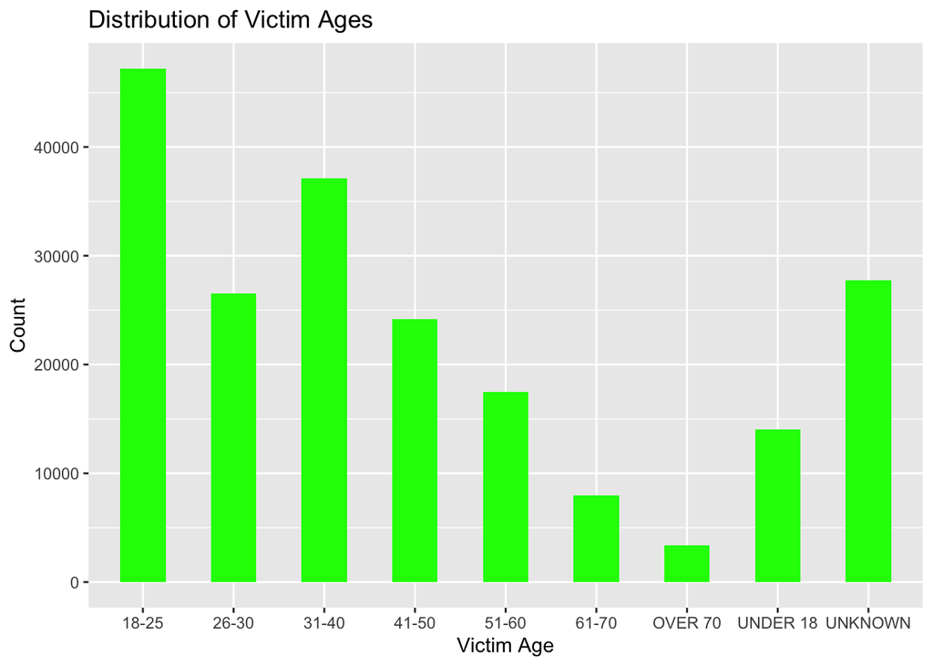

```r
ggplot(crime, aes(x = VICTIM_AGE)) +  #set x as VICTIM_AGE variable
  geom_bar(fill = "green", width = 0.5) +  #create bar plot with green bars and width 0.5
  labs(x = "Victim Age", y = "Count", title = "Distribution of Victim Ages") #add x-axis, y-axis and title labels
```

Create Pie Chart of Suspect Ages

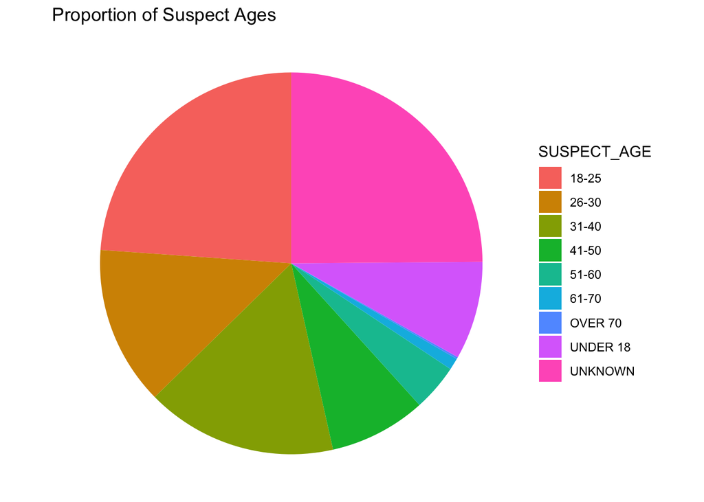

```r
#pie chart of suspect races
ggplot(crime, aes(x = "", fill = SUSPECT_AGE)) +
  geom_bar(width = 1) +
  coord_polar(theta = "y") +
  labs(x = "", y = "", title = "Proportion of Suspect Ages") + #add x-axis, y-axis and title labels
  theme_void() +  #remove unnecessary background elements
  theme(legend.position = "right") #adjust the legend position
```

Create grouped bar chart to see the proportion between victim gender and suspect gender

```r
filtered_data <- crime %>% #filter rows with empty VICTIM_GENDER and SUSPECT_GENDER
  filter(VICTIM_GENDER != "", SUSPECT_GENDER != "")


gender_counts <- filtered_data %>%
  group_by(VICTIM_GENDER, SUSPECT_GENDER) %>% #calculate frequency counts of Victim Gender and Suspect Gender combinations
  summarise(Frequency = n())
```

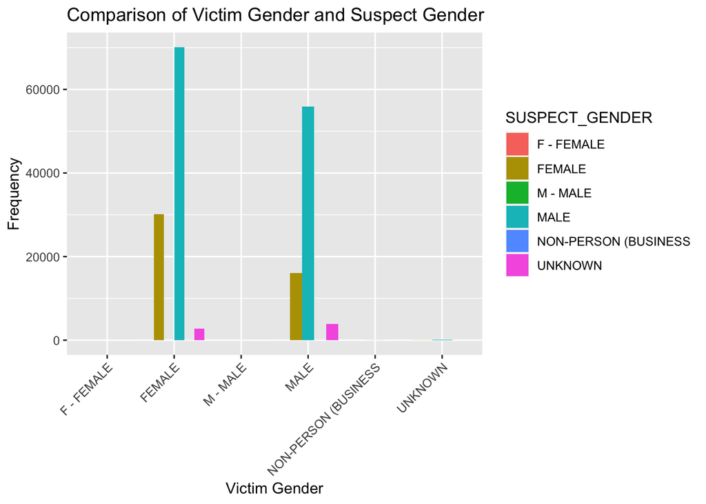

```r
#create grouped bar chart of Victim Gender and Suspect Gender
ggplot(gender_counts, aes(x = VICTIM_GENDER, y = Frequency, fill = SUSPECT_GENDER)) +
  geom_bar(stat = "identity", position = "dodge") +
  labs(x = "Victim Gender", y = "Frequency", title = "Comparison of Victim Gender and Suspect Gender") + #add x-axis, y-axis and title labels
  theme(axis.text.x = element_text(angle = 45, hjust = 1)) #customize x-axis text angle and justification
```

Create scatterplot to see most Uniform Crime Reporting of total number of victims

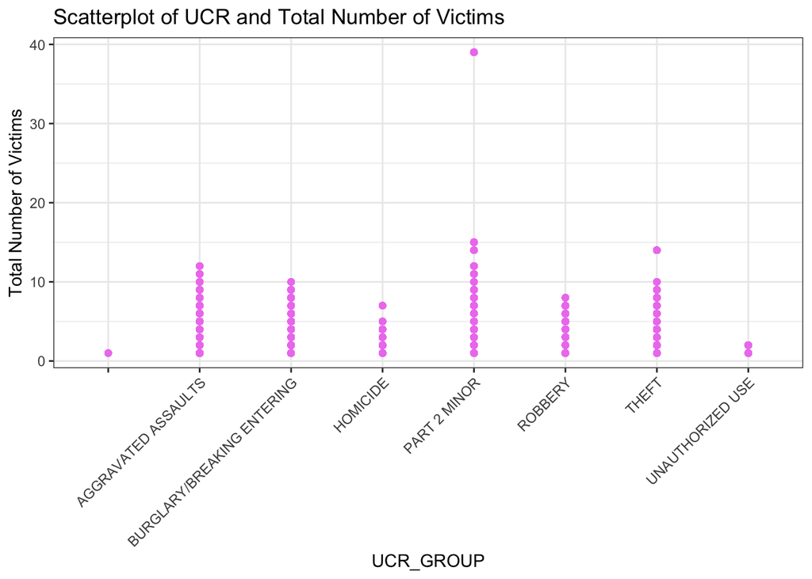

```r
filtered_data <- crime %>%
  filter(!is.na(UCR_GROUP) & !is.na(TOTALNUMBERVICTIMS))  #filter rows with empty UCR_GROUP and TOTALNUMBERVICTIMS


ggplot(filtered_data, aes(x = UCR_GROUP, y = TOTALNUMBERVICTIMS)) +  #set x-axis as UCR_GROUP and y as TOTALNUMBERVICTIMS
  geom_point(color = "violet") + #create scatterplot with violet color
  labs(x = "UCR_GROUP", y = "Total Number of Victims", title = "Scatterplot of UCR and Total Number of Victims") + #add x-axis, y-axis and title labels
  theme_bw() + #set theme to black and white
  theme(axis.text.x = element_text(angle = 45, hjust = 1)) #customize x-axis text angle and justification
```

Extra analysis: Create a map of Ohio where the incidents happen most

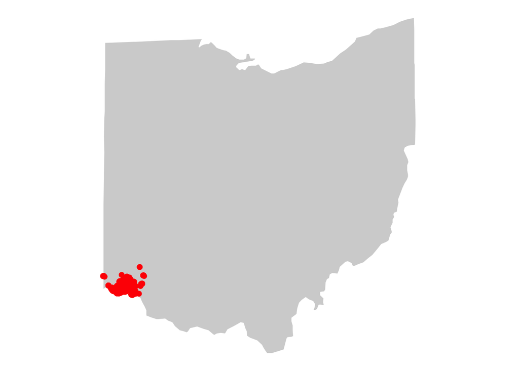

```r
ohio_crime_data <- crime %>% #create a variable ohio_crime_data
    filter(!is.na(LATITUDE_X) & !is.na(LONGITUDE_X)) %>%
    filter(CPD_NEIGHBORHOOD %in% c("WEST PRICE HILL", "SEDAMSVILLE"))

ohio_zip_codes <- unique(crime$ZIP) #retrieve unique zip codes

#remove any missing or NA values from the ZIP codes
ohio_zip_codes <- ohio_zip_codes[!is.na(ohio_zip_codes)]

ohio_crime_data <- crime %>%
  filter(!is.na(LATITUDE_X) & !is.na(LONGITUDE_X)) %>%
  filter(ZIP %in% ohio_zip_codes)

ohio_map <- map_data("state", region = "ohio") #select region ohio

ggplot() +
  geom_polygon(data = ohio_map, aes(x = long, y = lat, group = group), fill = "lightgray", color = "white") + #fill the map color with lightgray
  coord_map(xlim = range(ohio_map$long), ylim = range(ohio_map$lat)) +
  theme_void() +
  geom_point(data = ohio_crime_data, aes(x = LONGITUDE_X, y = LATITUDE_X), color = "red", size = 2) #plot the data in red color
```